# Scanpy in R

# What is Scanpy?

Scanpy is a scalable Python toolkit for analyzing single-cell gene expression data. It includes functionality commonly used during an analysis of scRNA-seq data including quality control, clustering of cells and testing for marker genes. For more information please have a look at the [Scanpy documentation](https://scanpy.readthedocs.io/en/latest/) or read the [associated publication](https://doi.org/10.1186/s13059-017-1382-0).

# Why would I want to use it from R?

There are various reasons you may want to interact with the Scanpy package from R. You may already be using Scanpy for your project but want to use an R package for a section of your analysis or your project but be R based and you want to use some of Scanpy’s functionality.

# What is covered in this tutorial?

This tutorial will cover how to set up a environment that lets you interact with Scanpy from R. It will demonstrate some of the functions in Scanpy but it won’t cover everything the package can do or how best to use Scanpy for your analysis. For more details about what Scanpy can do please refer to the tutorials and other information in the [Scanpy documentation](https://scanpy.readthedocs.io/en/latest/).

# Setting up

To use Scanpy from R you will (unsurprisingly) need both an R and Python environment set up. If you are mostly an R user the easiest approach is to use the **{renv}** package to setup and manage these environments. This is what we will do for this tutorial. If you are primarily a Python user you may find it easier to create your own **conda** or **virtualenv** environment. The main thing is to have both R and Python available (with the required packages installed), however it is highly recommended you use some kind of environment system to improve the reproducibilty of your project.

## Using **{renv}**

The [**{renv}**](https://rstudio.github.io/renv/) package helps you reproducible environments for an R project. These environments are designed to be isolated, portable and reproducible. This is similar to **conda** environments but they are confined to a specific project directory. Please refer to the [**{renv}** documentation](https://rstudio.github.io/renv/) for more details.

### Creating the R environment

To use **{renv}** we first need to make sure it is installed:

```r
install.packages("renv")
```

We can then ask **{renv}** to create an envronment for us:

```r
renv::init()
```

This command creates a new `renv/` folder where your installed packages (and some other things) will be stored and a `renv.lock` file which will be used to record the package versions. It will also create (or modify) the `.Rprofile` file to make sure the environment is activated. Once we have this environment activated we can install/remove packages but they will be kept separate from the global package environment. If you already have files with R code in this directory **{renv}** will attempt to find which packages you are using and install them into your new library. By default `renv::init()` will create the environment in the current working directory but you can also tell it to create it somewhere else by setting the `project` argument.

### Creating the Python environment

As we are going to be using Python we need to make sure we have the [**{reticulate}**](https://rstudio.github.io/reticulate/) package installed in our new environment:

```r
renv::install("reticulate")
```

This package provides a set of tools for interoperability between Python and R (the Python equivalent is the [**rpy2** package](https://rpy2.github.io/)). This includes calling Python functions from R, translating between Python and R objects and managing Python environments from R. For more details see the [**{reticulate}** documentation](https://rstudio.github.io/reticulate/).

Once **{reticulate}** is installed we can tell **{renv}** that we also want to use a Python evironment:

```r
renv::use_python()
```

Unless you specify a Python version with the `python` argument or the `RETICULATE_PYTHON` environment variable is set your default Python installation will be used. By default yhe type of environment created depends on your operating system (**virtualenv** on Linux/macOS or **conda** on Windows) but if you have a preference this can be controlled using the `type` argument.

If you choose not to use **{renv}** a Python environment can also be created using the `reticulate::use_python()` and `reticulate::use_virtualenv()`/`reticulate::use_condaenv()` functions.

## Installing packages

### R packages

Use the following command to install the R packages used during this tutorial:

```r
pkgs <- c(
    "renv",
    "reticulate",
    "png",
    "ggplot2",
    "BiocManager",
    "Seurat"
)

bioc_pkgs <- c(
    "SingleCellExperiment",
    "scater",
    "multtest"
)

# If you are using an {renv} environment
renv::install(pkgs)

# Otherwise do it the normal way
install.packages(pkgs)

# Install Bioconductor packages
BiocManager::install(bioc_pkgs, update = FALSE)
```

### Python packages

The following Python packages are required for this tutorial:

```r
py_pkgs <- c(
    "scanpy",
    "python-igraph",
    "louvain"
)
```

To install them from R we can use `reticulate::py_install()`:

```r
reticulate::py_install(py_pkgs)
```

If you are not using **{renv}**/**{reticulate}** to manage your Python environment please install them in the way you would normally.

### **{renv}** snapshot

If you have chosen to use an **{renv}** environment you should run the `renv::snapshot()` command after installing packages. This records the changes you have made so they can be restored later if necessary.

```r
renv::snapshot()
```

# Alternative approaches

There are two approaches you can use to interact with Python packages from R, both of which we will describe here.

The first approach is to perform our analysis in an [**R Markdown**](https://rmarkdown.rstudio.com/) document. **R Markdown** is a text-based document format that lets you combine text and code. When the document is rendered the code is evaluated and the results is included in the output document, which can be several different formats including HTML, PDF and DOCX. Although it has been primarily designed to be used with R code **R Markdown** supports “engines” for several programming languages including Python. **R Markdown** documents that include Python code maintain a single Python session for the all the code chunks in a document. This lets us create a single document that contains native R **and** Python code and lets us transfer object between them as required.

The second approach is to access Scanpy functions from R using the **{reticulate}** interface. While this means we can’t copy Python code from examples directly it doesn’t lock us into using **R Markdown** and may be easier for those who are comfortable with R code but unfamiliar with Python. It is also possible to use this approach inside an **R Markdown** document rather than using native Python code.

If you are already using **R Markdown** documents for your analysis it likely makes sense for you to use that approach, otherwise the choice is up to you. Which approach you choose to use may depend on a range of factors including which programming language you are more comfortable with and how much of your analysis you intend to perform using either language.

# The **R Markdown** approach

First let’s work through the **R Markdown** approach. We won’t cover the all the basics of **R Markdown** documents so if you haven’t used them before you may want to work through an introductory tutorial first.

We will start by loading some R libaries.

```r
suppressPackageStartupMessages({
    library("reticulate")
    library("ggplot2")
    library("SingleCellExperiment")
    library("scater")
    library("Seurat")
})
```

We will also import Scanpy in a Python chunk. A Python chunk begins with `` ```{python} `` instead of `` ```{r} ``. If you are using RStudio you can easily create on by clickin `Insert > Python` in the **R Markdown** editor pane.

```python
import scanpy as sc
```

## Load data

As this tutorial focuses on the interaction between R and Scanpy rather than the features of the package itself we will work with the processed PBMC3K dataset. This is a dataset of around 3000 peripheral blood mononuclear cells that was produced by 10x Genomics and has been processed as described in the Scanpy [PBMC3K tutorial](https://scanpy-tutorials.readthedocs.io/en/latest/pbmc3k.html).

> **NOTE:** Running this command will download the dataset to a `data/` directory if it doesn’t already exist.

```python
adata = sc.datasets.pbmc3k_processed()
```

The data is returned as an [`AnnData`](https://anndata.readthedocs.io/en/stable/) object. This is similar to a `SingleCellExperiment` or `Seurat` object used by R packages and stores matrices of expression values as well as annotation for cells and features and various other data structures created during analysis such as embeddings and nearest neighbour graphs. A key difference is that `AnnData` matrices are transposed compared to those used by R packages, the rows represent cells and the columns represent features. Please refer to the [**anndata** documentation](https://anndata.readthedocs.io/en/stable/) for more details about this data structure.

Let’s have a look at what this one includes.

```python
adata
```

```
## AnnData object with n_obs × n_vars = 2638 × 1838
##     obs: 'n_genes', 'percent_mito', 'n_counts', 'louvain'
##     var: 'n_cells'
##     uns: 'draw_graph', 'louvain', 'louvain_colors', 'neighbors', 'pca', 'rank_genes_groups'
##     obsm: 'X_pca', 'X_tsne', 'X_umap', 'X_draw_graph_fr'
##     varm: 'PCs'
```

## Using Scanpy functions

With the **R Markdown** approach using Scanpy functions is easy. We simply create a new Python chunk and use standard Python commands. For example, let’s plot a UMAP of the Louvain clustering already stored in the object:

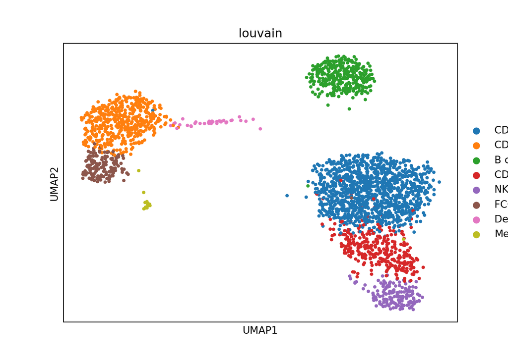

```python
sc.pl.umap(adata, color='louvain')
```

We could also re-cluster the data at a higher resolution and re-plot the UMAP. We store the new clustering in an observation variable called “louvain_2”.

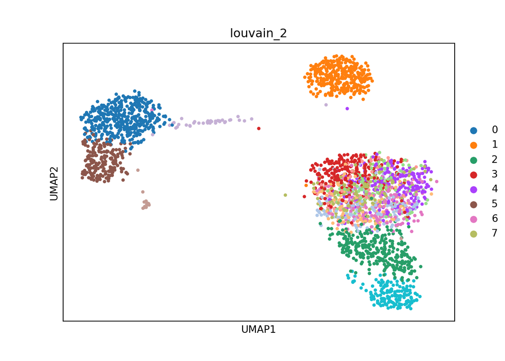

```python
sc.tl.louvain(adata, resolution=2, key_added='louvain_2')
sc.pl.umap(adata, color='louvain_2')
```

## Converting from Python to R

Python objects can be accessed from R using the special `py` variable (as long as we have loaded the **{reticulate}** package). This variable is accessed as a `list` where each item in the list is an object in the Python session. For example let’s create a list in Python:

```python
a_list = ['My', 'list', 'of', 'things']
print(a_list)
```

```
## ['My', 'list', 'of', 'things']
```

We can access that exact same list in R:

```r
py$a_list
```

```
## [1] "My"     "list"   "of"     "things"
```

We can even modify the list in R…

```r
py$a_list[4] <- "words"
```

…and the changes are changes can be seen in Python.

```python
print(a_list)
```

```
## ['My', 'list', 'of', 'words']
```

For several common data structures the objects are automatically converted to their equivalent type in R.

```r
class(py$a_list)
```

```
## [1] "character"
```

This is also true for some more complex data structures. For example, variables associated with observations (cells) are stored as a **pandas** `DataFrame` in our `AnnData` object but are converted to a `data.frame` in R.

```r
class(py$adata$obs)
```

```
## [1] "data.frame"
```

We can use this object directly in our R session. For example let’s plot the number of genes expressed per cell against the number of counts using **{ggplot2}**.

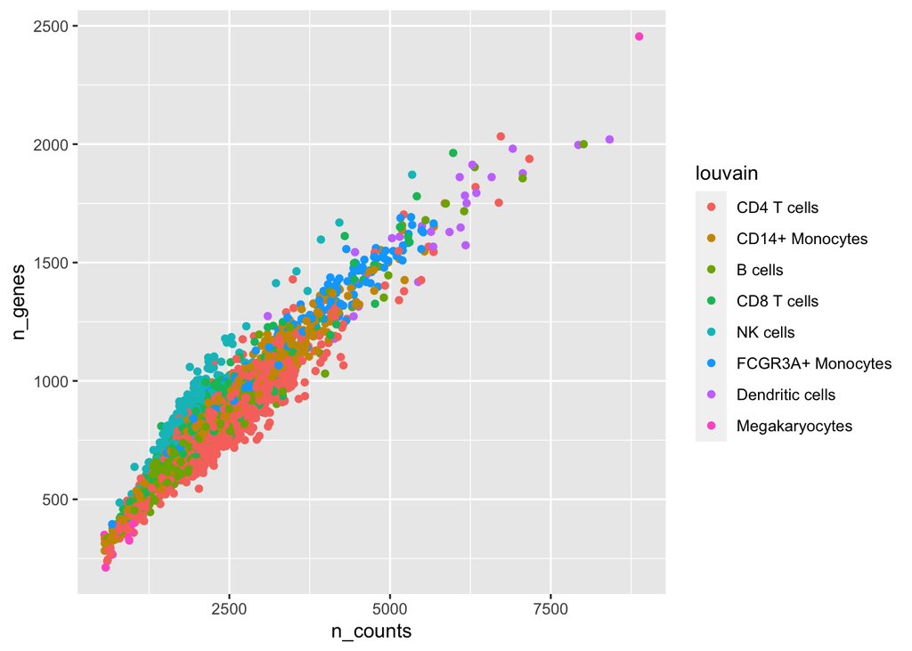

```r
ggplot(py$adata$obs, aes(x = n_counts, y = n_genes, colour = louvain)) +
    geom_point()
```

### Creating a `SingleCellExperiment` object from `AnnData`

Many of the R packages for scRNA-seq analysis are part of the [Bioconductor](https://bioconductor.org/) project and use the [`SingleCellExperiment`](https://www.bioconductor.org/packages/release/bioc/html/SingleCellExperiment.html) object. To make use of these packages you may need to create one of these objects. Many of the parts of `SingleCellExperiment` and `AnnData` objects are equivalent and can be converted directly.

```r
sce <- SingleCellExperiment(
    assays      = list(logcounts = t(py$adata$X)),
    colData     = py$adata$obs,
    rowData     = py$adata$var,
    reducedDims = list(umap = py$adata$obsm["X_umap"])
)
sce
```

```
## class: SingleCellExperiment
## dim: 1838 2638
## metadata(0):
## assays(1): logcounts
## rownames(1838): TNFRSF4 CPSF3L ... S100B PRMT2
## rowData names(1): n_cells
## colnames(2638): AAACATACAACCAC-1 AAACATTGAGCTAC-1 ... TTTGCATGAGAGGC-1
##   TTTGCATGCCTCAC-1
## colData names(5): n_genes percent_mito n_counts louvain louvain_2
## reducedDimNames(1): umap
## spikeNames(0):
## altExpNames(0):
```

Note that we haven’t copied everything to our new `SingleCellExperiment` but only what is directly mappable and most likely to be useful. If you need some of the other information stored in the `AnnData` object it should be possible to transfer that as well but you would need to decide where it best fits in the `SingleCellExperiment`. We have also made some decisions about how to name things. For example we have stored the main `X` expression matrix in the `logcounts` assay as this represents a similar transformation of the expression data and functions in some packages expect this assay to exist.

To show that we can use this object let’s plot our UMAP again in R using the [**{scater}**](https://www.bioconductor.org/packages/release/bioc/html/scater.html) package.

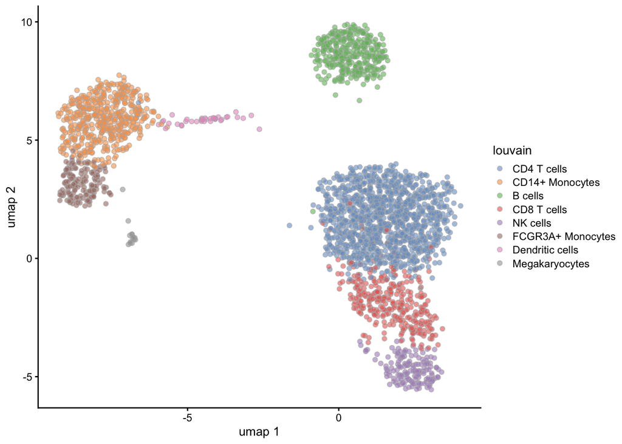

```r
plotReducedDim(sce, "umap", colour_by = "louvain")
```

Because the embedding has already been calculated in Scanpy we use the `scater::plotReducedDim()` function here but we could also ask **{scater}** to computer new embeddings for us.

### Creating a `Seurat` object from `AnnData`

The other object that is often used by R scRNA-seq analysis packages is the [`Seurat`](https://satijalab.org/seurat/) object. We can create one of these in a similar way. Please see the [**{Seurat}** documentation](https://satijalab.org/seurat/) for more details about this object.

```r
# Get the expression matrix
exprs <- t(py$adata$X)
colnames(exprs) <- py$adata$obs_names$to_list()
rownames(exprs) <- py$adata$var_names$to_list()
# Create the Seurat object
seurat <- CreateSeuratObject(exprs)
# Set the expression assay
seurat <- SetAssayData(seurat, "data", exprs)
# Add observation metadata
seurat <- AddMetaData(seurat, py$adata$obs)
# Add fetaure metadata
seurat[["RNA"]][["n_cells"]] <- py$adata$var["n_cells"]
# Add embedding
embedding <- py$adata$obsm["X_umap"]
rownames(embedding) <- py$adata$obs_names$to_list()
colnames(embedding) <- c("umap_1", "umap_2")
seurat[["umap"]] <- CreateDimReducObject(embedding, key = "umap_")
seurat
```

```
## An object of class Seurat
## 1838 features across 2638 samples within 1 assay
## Active assay: RNA (1838 features)
##  1 dimensional reduction calculated: umap
```

The process for creating a `Seurat` object is more complex that creating a `SingleCellExperiment` and requires creating several other objects. The `Seurat::CreateSeuratObject()` function expects a single matrix that contains raw count data. We don’t have that here so we use the normalised expression matrix instead. If we did have counts it would be better to use those. `Seurat` objects can have multiple “assays” (the default is “RNA”) which can each have three data representations (“counts”, “data” and “scale.data”). We have placed the expression matrix in the “data” slot here but which is most appropriate depends on the data you are copying. Metadata for observations can be added using the `Seurat::AddMetaData()` function but feature metadata must be added manually to the correct assay. We also add a `DimReduc` object holding the UMAP embedding.

> **NOTE:** The `Seurat::ReadH5AD()` function can be used to read the `.h5ad` format commonly used to save `AnnData` objects to disk. This is another way to convert between the formats and will produce a more complete conversion at the cost of writing to disk.

The functions in **{Seurat}** (and related packages) can now be used with this object. Let’s recreate our UMAP plot:

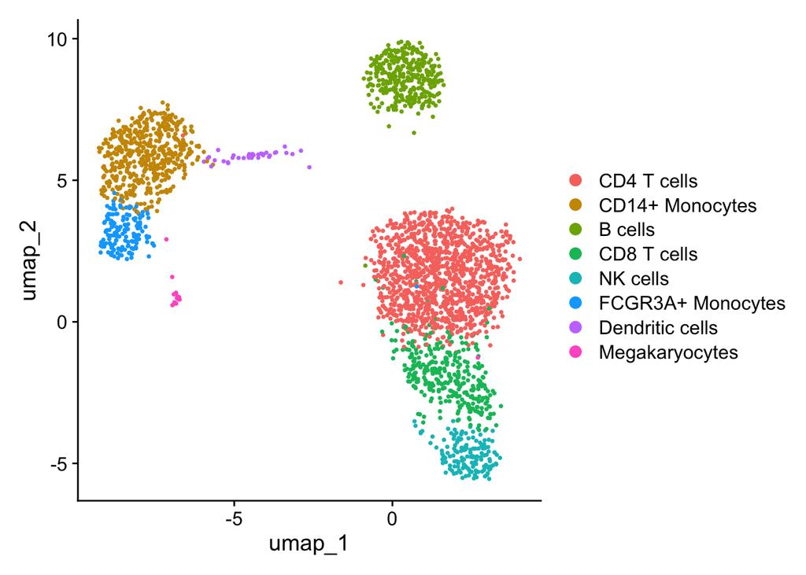

```r
seurat <- SetIdent(seurat, value = "louvain")
DimPlot(seurat, reduction = "umap")
```

## Converting from R to Python

The reverse conversion can be done in a similar way. Just like there is a special `py` variable in the R session there is a special `r` variable in the Python section. Here is a quick example:

```r
another_list <- c("Some", "more", "things")
```

In Python the list looks like this.

```python
r.another_list
```

```
## ['Some', 'more', 'things']
```

Notice that we use the `.` operator in Python rather than the `$` operator we used in R.

### Creating `AnnData` from `SingleCellExperiment`

Let’s pretend we have completed some analysis in our R session and we want to transfer the results back to our `AnnData` object in the Python section.

Because some of the parts of the `SingleCellExperiment` use non-standard classes (such as the Bioconductor `DataFrame` class) that can’t be automatically converted by **{reticulate}** it is easiest to first extract the parts we want.

```r
exprs <- assay(sce, "logcounts")
col_data <- as.data.frame(colData(sce))
row_data <- as.data.frame(rowData(sce))
embedding <- reducedDim(sce, "umap")
```

We can then had any variables we want to our `AnnData` object in Python:

```python
adata.obs['sce_louvain'] = r.col_data['louvain']
```

We could also create a new `AnnData` object by transferring everything we extracted from the `SingleCellExperiment`:

```python
adata_sce = sc.AnnData(X = r.exprs.T, obs = r.col_data, var = r.row_data)
adata_sce.obsm['umap'] = r.embedding
```

This new `AnnData` can also be used with Scanpy.

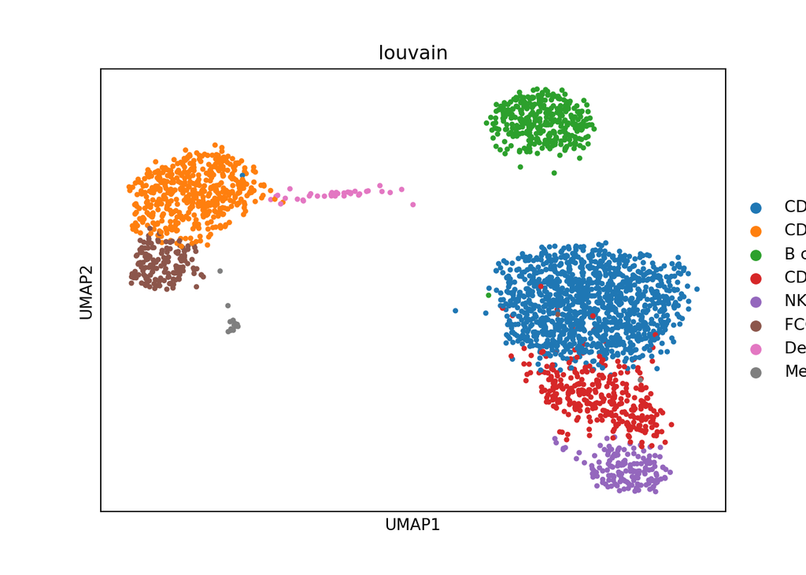

```python
sc.pl.umap(adata_sce, color='louvain')
```

### Creating `AnnData` from `Seurat`

The process for creating an `AnnData` object from a `Seurat` object is very similar. First we extract the parts we want:

```r
exprs <- GetAssayData(seurat)
meta <- seurat[[]]
feature_meta <- GetAssay(seurat)[[]]
embedding <- Embeddings(seurat, "umap")
```

Then we can construct a new `AnnData` in a Python chunk.

```python
adata_seurat = sc.AnnData(X = r.exprs.T, obs = r.meta, var = r.feature_meta)
adata_seurat.obsm['umap'] = r.embedding
```

This object should also be compatible with Scanpy functions.

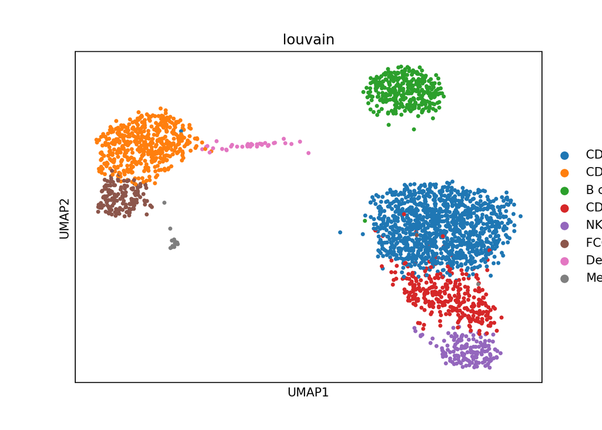

```python
sc.pl.umap(adata_seurat, color='louvain')
```

# The **{reticulate}** approach

The **{reticulate}** approach involves calling Scanpy functions from an R session. This means that we keep everything inside a single R session and only need to write R code but the downside is we cannot directly copy examples that have been written in Python.

We first need to load the R packages we need.

```r
suppressPackageStartupMessages({
    library("reticulate")
    library("ggplot2")
    library("SingleCellExperiment")
    library("scater")
    library("Seurat")
})
```

This time to load a Python package we don’t use a Python chunk but we use the `reticulate::import()` function.

```r
sc <- import("scanpy")
```

## Load data

To load the dataset we will use the Scanpy `pbmc3k_processed()` function. To use this from R the syntax is mostly the same but we replace the “.” characters between modules with the “$” operator in R.

```r
adata <- sc$datasets$pbmc3k_processed()
```

If we print this object we should see the same output we saw in the corresponding Python chunk in the **R Markdown** approach.

```r
adata
```

```
## AnnData object with n_obs × n_vars = 2638 × 1838
##     obs: 'n_genes', 'percent_mito', 'n_counts', 'louvain'
##     var: 'n_cells'
##     uns: 'draw_graph', 'louvain', 'louvain_colors', 'neighbors', 'pca', 'rank_genes_groups'
##     obsm: 'X_pca', 'X_tsne', 'X_umap', 'X_draw_graph_fr'
##     varm: 'PCs'
```

## Using Scanpy functions

Other Scanpy functions can be called from R in the same way. Here is an example adding another clustering resolution.

```r
sc$tl$louvain(adata, resolution = 2, key_added = "louvain_2")

colnames(adata$obs)
```

```
## [1] "n_genes"      "percent_mito" "n_counts"     "louvain"      "louvain_2"
```

> **NOTE:** We don’t show a plotting example here as the plot will appear in a new window. It is still possible to use these function though.

## Converting from Python to R

Accessing parts of our `AnnData` object is simpler than it was with the **R Markdown** approach. We don’t have to worry about a special variable we can just extract information from the `AnnData` using standard R operators. This works particularly well for those data structures that are automatically converted by **{reticulate}**.

```r
head(adata$obs)
```

```
##                  n_genes percent_mito n_counts         louvain louvain_2
## AAACATACAACCAC-1     781  0.030177759     2419     CD4 T cells         6
## AAACATTGAGCTAC-1    1352  0.037935957     4903         B cells         1
## AAACATTGATCAGC-1    1131  0.008897362     3147     CD4 T cells        10
## AAACCGTGCTTCCG-1     960  0.017430846     2639 CD14+ Monocytes         5
## AAACCGTGTATGCG-1     522  0.012244898      980        NK cells         8
## AAACGCACTGGTAC-1     782  0.016643550     2163     CD8 T cells         9
```

```r
head(adata$var)
```

```
##          n_cells
## TNFRSF4      155
## CPSF3L       202
## ATAD3C         9
## C1orf86      501
## RER1         608
## TNFRSF25     170
```

```r
adata$X[1:5, 1:5]
```

```
##            [,1]       [,2]        [,3]       [,4]       [,5]
## [1,] -0.1714695 -0.2808120 -0.04667679 -0.4751688 -0.5440238
## [2,] -0.2145822 -0.3726529 -0.05480444 -0.6833915  0.6339506
## [3,] -0.3768875 -0.2950843 -0.05752750 -0.5209721  1.3326473
## [4,] -0.2852409 -0.2817346 -0.05222673 -0.4849288  1.5726788
## [5,] -0.2564834 -0.2203940 -0.04680008 -0.3458593 -0.3334090
```

We can also directly pass these objects to R functions:

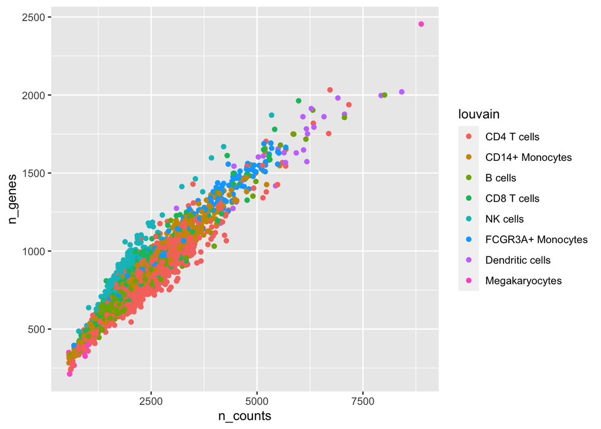

```r
ggplot(adata$obs, aes(x = n_counts, y = n_genes, colour = louvain)) +
    geom_point()
```

Some objects cannot be converted automatically. In this case you need to ask **{reticulate}** to run some Python code to convert the object to a format R can understand. We can them get the result from the magic `py` variable.

```r
py_run_string("draw_graph = r.adata.uns['draw_graph']")

py$draw_graph
```

```
## $params
## $params$layout
## [1] "fr"
##
## $params$random_state
## [1] 0
```

### Creating a `SingleCellExperiment` object from `AnnData`

Creating a `SingleCellExperiment` is very similar to what we did in the **R Markdown** approach but with slightly simpler code.

```r
sce <- SingleCellExperiment(
    assays      = list(logcounts = t(adata$X)),
    colData     = adata$obs,
    rowData     = adata$var,
    reducedDims = list(umap = adata$obsm["X_umap"])
)
sce
```

```
## class: SingleCellExperiment
## dim: 1838 2638
## metadata(0):
## assays(1): logcounts
## rownames(1838): TNFRSF4 CPSF3L ... S100B PRMT2
## rowData names(1): n_cells
## colnames(2638): AAACATACAACCAC-1 AAACATTGAGCTAC-1 ... TTTGCATGAGAGGC-1
##   TTTGCATGCCTCAC-1
## colData names(5): n_genes percent_mito n_counts louvain louvain_2
## reducedDimNames(1): umap
## spikeNames(0):
## altExpNames(0):
```

We can then use this object as normal:

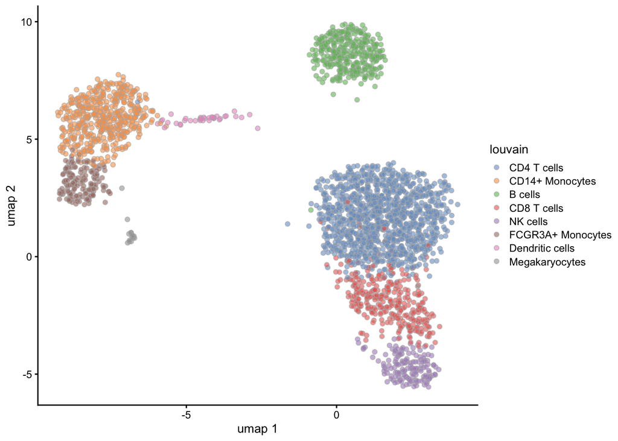

```r
plotReducedDim(sce, "umap", colour_by = "louvain")
```

### Creating a `Seurat` object from `AnnData`

The same is true when creating a `Seurat` object.

```r
exprs <- t(adata$X)
colnames(exprs) <- adata$obs_names$to_list()
rownames(exprs) <- adata$var_names$to_list()
# Create the Seurat object
seurat <- CreateSeuratObject(exprs)
# Set the expression assay
seurat <- SetAssayData(seurat, "data", exprs)
# Add observation metadata
seurat <- AddMetaData(seurat, adata$obs)
# Add fetaure metadata
seurat[["RNA"]][["n_cells"]] <- adata$var["n_cells"]
# Add embedding
embedding <- adata$obsm["X_umap"]
rownames(embedding) <- adata$obs_names$to_list()
colnames(embedding) <- c("umap_1", "umap_2")
seurat[["umap"]] <- CreateDimReducObject(embedding, key = "umap_")
seurat
```

```
## An object of class Seurat
## 1838 features across 2638 samples within 1 assay
## Active assay: RNA (1838 features)
##  1 dimensional reduction calculated: umap
```

This should then function as a normal `Seurat` object:

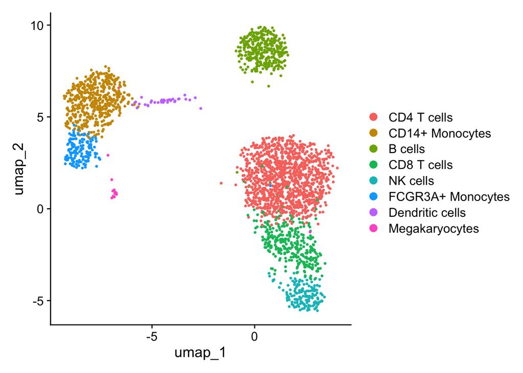

```r
seurat <- SetIdent(seurat, value = "louvain")
DimPlot(seurat, reduction = "umap")
```

## Converting from R to Python

Converting from R to Python is a bit different than when using the **{R Markdown}** approach as we can do everything in the R session in many cases.

```r
var <- "n_genes"

head(adata$obs[var])
```

```
##                  n_genes
## AAACATACAACCAC-1     781
## AAACATTGAGCTAC-1    1352
## AAACATTGATCAGC-1    1131
## AAACCGTGCTTCCG-1     960
## AAACCGTGTATGCG-1     522
## AAACGCACTGGTAC-1     782
```

When this doesn’t work we can use the magic `r` variable with the `reticulate::py_run_string()` function (as shown before) or the `reticulate::py_eval()` function. Which one to use depends on what you are trying to do.

```r
py_eval("r.adata.obs[r.var].head()")
```

```
## index
## AAACATACAACCAC-1     781
## AAACATTGAGCTAC-1    1352
## AAACATTGATCAGC-1    1131
## AAACCGTGCTTCCG-1     960
## AAACCGTGTATGCG-1     522
## Name: n_genes, dtype: int64
```

### Creating `AnnData` from `SingleCellExperiment`

Because we are working only in R we don’t need to first extract and convert the part of the `SingleCellExperiment` we want before creating a new `AnnData`. Instead we can do everthing at once.

```r
adata_sce <- sc$AnnData(
    X   = t(logcounts(sce)),
    obs = as.data.frame(colData(sce)),
    var = as.data.frame(rowData(sce))
)
adata_sce$obsm$update(umap = reducedDim(sce, "umap"))

adata_sce
```

```
## AnnData object with n_obs × n_vars = 2638 × 1838
##     obs: 'n_genes', 'percent_mito', 'n_counts', 'louvain', 'louvain_2'
##     var: 'n_cells'
##     obsm: 'umap'
```

### Creating `AnnData` from `Seurat`

The same is true when creating a new `AnnData` from a `Seurat` object.

```r
adata_seurat <- sc$AnnData(
    X   = t(GetAssayData(seurat)),
    obs = seurat[[]],
    var = GetAssay(seurat)[[]]
)
adata_seurat$obsm$update(umap = Embeddings(seurat, "umap"))

adata_seurat
```

```
## AnnData object with n_obs × n_vars = 2638 × 1838
##     obs: 'orig.ident', 'nCount_RNA', 'nFeature_RNA', 'n_genes', 'percent_mito', 'n_counts', 'louvain', 'louvain_2'
##     var: 'n_cells'
##     obsm: 'umap'
```